# Activity 1 — Task 1: Data Preprocessing

Group 08

## Read Data

We start by loading the raw dataset `ds_salaries.csv` (607 observations, 11 variables) and inspecting its structure.

Two currency-related columns are present: `salary` (gross pay in the original currency, e.g. EUR, GBP, INR) and `salary_currency` (the ISO 4217 code for that column). Salary is reported in many currencies, which are not directly comparable; the dataset also supplies `salary_in_usd`, the same value already converted to US dollars at the collection-time exchange rate. We therefore use `salary_in_usd` as the single response throughout and do not model `salary`/`salary_currency` themselves - they carry no additional predictive information beyond the USD value and would only introduce non-comparable, multi-currency redundancy.

```r
library(tidyverse)
data <- read.csv("dataset/ds_salaries.csv")
head(data)
```

|  | X | work_year | experience_level | employment_type | job_title | salary | salary_currency | salary_in_usd | employee_residence | remote_ratio | company_location | company_size |
| --- | --- | --- | --- | --- | --- | --- | --- | --- | --- | --- | --- | --- |
| 1 | 0 | 2020 | MI | FT | Data Scientist | 70000 | EUR | 79833 | DE | 0 | DE | L |
| 2 | 1 | 2020 | SE | FT | Machine Learning Scientist | 260000 | USD | 260000 | JP | 0 | JP | S |
| 3 | 2 | 2020 | SE | FT | Big Data Engineer | 85000 | GBP | 109024 | GB | 50 | GB | M |
| 4 | 3 | 2020 | MI | FT | Product Data Analyst | 20000 | USD | 20000 | HN | 0 | HN | S |
| 5 | 4 | 2020 | SE | FT | Machine Learning Engineer | 150000 | USD | 150000 | US | 50 | US | L |
| 6 | 5 | 2020 | EN | FT | Data Analyst | 72000 | USD | 72000 | US | 100 | US | L |

```r
summary(data)
```

```
##        X           work_year     experience_level  employment_type
##  Min.   :  0.0   Min.   :2020   Length   :607     Length   :607
##  1st Qu.:151.5   1st Qu.:2021   N.unique :  4     N.unique :  4
##  Median :303.0   Median :2022   N.blank  :  0     N.blank  :  0
##  Mean   :303.0   Mean   :2021   Min.nchar:  2     Min.nchar:  2
##  3rd Qu.:454.5   3rd Qu.:2022   Max.nchar:  2     Max.nchar:  2
##  Max.   :606.0   Max.   :2022
##      job_title       salary          salary_currency salary_in_usd
##  Length   :607   Min.   :    4000   Length   :607    Min.   :  2859
##  N.unique : 50   1st Qu.:   70000   N.unique : 17    1st Qu.: 62726
##  N.blank  :  0   Median :  115000   N.blank  :  0    Median :101570
##  Min.nchar: 11   Mean   :  324000   Min.nchar:  3    Mean   :112298
##  Max.nchar: 40   3rd Qu.:  165000   Max.nchar:  3    3rd Qu.:150000
##                  Max.   :30400000                    Max.   :600000
##  employee_residence  remote_ratio     company_location    company_size
##  Length   :607      Min.   :  0.00   Length   :607     Length   :607
##  N.unique : 57      1st Qu.: 50.00   N.unique : 50     N.unique :  3
##  N.blank  :  0      Median :100.00   N.blank  :  0     N.blank  :  0
##  Min.nchar:  2      Mean   : 70.92   Min.nchar:  2     Min.nchar:  1
##  Max.nchar:  2      3rd Qu.:100.00   Max.nchar:  2     Max.nchar:  1
##                     Max.   :100.00
```

# 1 Data Preprocessing

## 1.1 Remove the ID column

The first column `X` is only a row index (0–606). It carries no information, so we remove it to avoid confusing the models later.

```r
data$X <- NULL
head(data)
```

|  | work_year | experience_level | employment_type | job_title | salary | salary_currency | salary_in_usd | employee_residence | remote_ratio | company_location | company_size |
| --- | --- | --- | --- | --- | --- | --- | --- | --- | --- | --- | --- |
| 1 | 2020 | MI | FT | Data Scientist | 70000 | EUR | 79833 | DE | 0 | DE | L |
| 2 | 2020 | SE | FT | Machine Learning Scientist | 260000 | USD | 260000 | JP | 0 | JP | S |
| 3 | 2020 | SE | FT | Big Data Engineer | 85000 | GBP | 109024 | GB | 50 | GB | M |
| 4 | 2020 | MI | FT | Product Data Analyst | 20000 | USD | 20000 | HN | 0 | HN | S |
| 5 | 2020 | SE | FT | Machine Learning Engineer | 150000 | USD | 150000 | US | 50 | US | L |
| 6 | 2020 | EN | FT | Data Analyst | 72000 | USD | 72000 | US | 100 | US | L |

## 1.2 Check for missing values and empty strings

```r
missing_values <- colSums(is.na(data))
print(missing_values) ### The dataset has no Na values
```

```
##          work_year   experience_level    employment_type          job_title
##                  0                  0                  0                  0
##             salary    salary_currency      salary_in_usd employee_residence
##                  0                  0                  0                  0
##       remote_ratio   company_location       company_size
##                  0                  0                  0
```

```r
empty_strings <- colSums(data == "")
print(empty_strings) ### The dataset has no empty strings
```

```
##          work_year   experience_level    employment_type          job_title
##                  0                  0                  0                  0
##             salary    salary_currency      salary_in_usd employee_residence
##                  0                  0                  0                  0
##       remote_ratio   company_location       company_size
##                  0                  0                  0
```

The dataset contains **no missing values** and **no empty strings**, so no imputation or deletion is needed.

## 1.3 Remove duplicate records

```r
duplicate_rows <- data[duplicated(data), ]
print(nrow(duplicate_rows)) ### 42 dupplicated rows
```

```
## [1] 42
```

```r
data <- data %>% distinct()
cat("Rows after removing duplicates:", nrow(data), "\n") ### 607 -> 565
```

```
## Rows after removing duplicates: 565
```

```r
stopifnot(nrow(data) == 565, sum(duplicated(data)) == 0)
stopifnot(sum(is.na(data)) == 0, sum(data == "") == 0)
```

42 rows are exact duplicates of other rows. We keep the first occurrence of each and remove the rest (**607 → 565**). Duplicates add no information and would double-count observations in every later statistic (means, ANOVA group sizes, model fitting).

## 1.4 Detect and handle outliers in `salary_in_usd`

### Boxplot of the raw salary

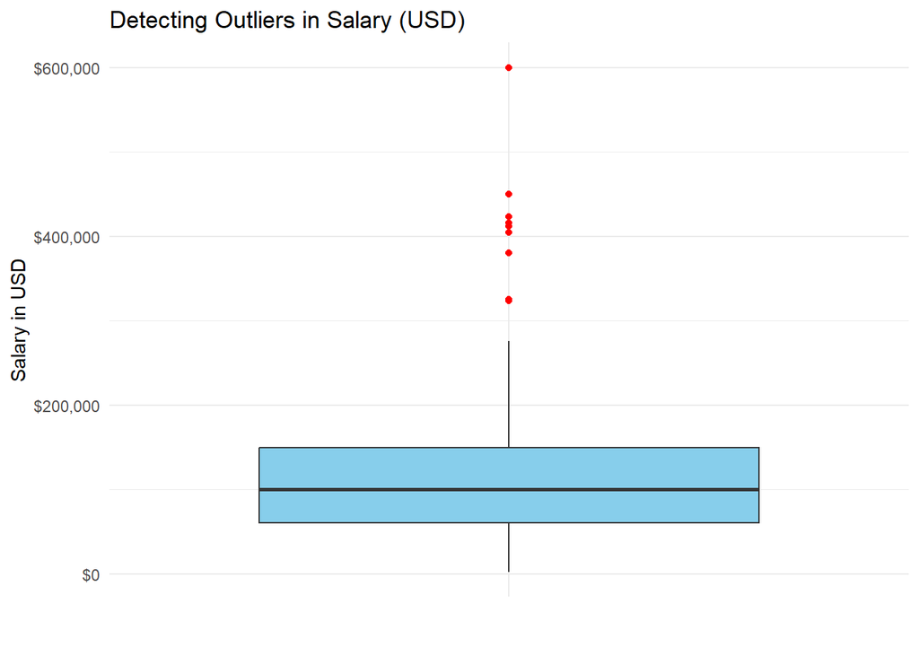

```r
ggplot(data, aes(x = "", y = salary_in_usd)) +
  geom_boxplot(fill = "skyblue", outlier.color = "red", outlier.shape = 16) +
  scale_y_continuous(labels = scales::dollar) +
  theme_minimal() +
  labs(title = "Detecting Outliers in Salary (USD)", x = "", y = "Salary in USD")
```

### IQR rule (global)

```r
Q1 <- quantile(data$salary_in_usd, 0.25)
Q3 <- quantile(data$salary_in_usd, 0.75)
IQR_value <- Q3 - Q1

lower_bound <- Q1 - 1.5 * IQR_value
upper_bound <- Q3 + 1.5 * IQR_value

outlier_rows <- data %>%
  filter(salary_in_usd < lower_bound | salary_in_usd > upper_bound)

cat("Total IQR Outliers Detected:", nrow(outlier_rows), "\n") # 10 outliers detected
```

```
## Total IQR Outliers Detected: 10
```

The IQR rule flags **10 observations** above 280,911 USD; none fall below the lower bound.

### Decision: keep the outliers and log-transform

```r
data$log_salary <- log(data$salary_in_usd) ### natural logarithm (ln)
```

We **keep all 10 rows**. They are the top earners of the sample — high earners across the seniority spectrum (Executive 4, Senior 3, Mid-level 3), all with US-based employers — not data-entry errors. Removing ~1.8% of an already small sample (565) would bias group means and group sizes, and winsorization would fabricate values. Instead, the skewness is handled at the model level by adding `log_salary = ln(salary_in_usd)`, which later tasks use as the response.

### Cross-check: per-group IQR within experience level

A single global IQR ignores the fact that salary naturally varies by experience level. To verify that our flags are just high earners within each group (not data errors), we repeat the IQR rule **within each experience level**:

```r
group_outliers <- data %>%
  group_by(experience_level) %>%
  mutate(gQ1 = quantile(salary_in_usd, 0.25),
         gQ3 = quantile(salary_in_usd, 0.75),
         gIQR = gQ3 - gQ1,
         is_group_outlier = salary_in_usd < (gQ1 - 1.5 * gIQR) |
                            salary_in_usd > (gQ3 + 1.5 * gIQR)) %>%
  ungroup()
print(table(group_outliers$experience_level, group_outliers$is_group_outlier))
```

```
##
##      FALSE TRUE
##   EN    86    2
##   EX    24    2
##   MI   203    5
##   SE   240    3
```

The flags are spread across all four levels (EN 2, MI 5, SE 3, EX 2), which confirms they are simply the top earners of each group — supporting our keep decision.

## 1.5 Group granular job titles into major categories

```r
data <- data %>%
  mutate(job_category = case_when(
    grepl("Director|Head|Manager|Lead", job_title, ignore.case = TRUE) ~ "Management_Lead",
    grepl("Research Scientist", job_title, ignore.case = TRUE) ~ "Research",
    grepl("Machine Learning|ML Engineer|ML Scientist|AI|Computer Vision|NLP|Deep Learning|Researcher",
          job_title, ignore.case = TRUE) ~ "ML_AI_Engineer",
    grepl("Data Engineer|Big Data|ETL|Cloud Data|Data Architect|Data Specialist|Data Science Engineer",
          job_title, ignore.case = TRUE) ~ "Data_Engineer",
    grepl("Data Scientist|Scientist", job_title, ignore.case = TRUE) ~ "Data_Scientist",
    grepl("Data Analyst", job_title, ignore.case = TRUE) ~ "Data_Analyst",
    TRUE ~ "Other"
  ))

stopifnot(sum(is.na(data$job_category)) == 0)

data$job_category <- factor(data$job_category)
print(table(data$job_category))
```

```
##
##    Data_Analyst   Data_Engineer  Data_Scientist Management_Lead  ML_AI_Engineer
##             101             151             143              58              81
##           Other        Research
##              15              16
```

Every title maps to exactly one category (the `stopifnot` assertion passes), and no title is left unmapped.

## 1.6 Encode categorical variables

### Ordinal encoding

`experience_level` and `company_size` have a natural order, so we encode them as ordinal integers. The raw character columns are kept alongside for the Factorial ANOVA in Task 3.

> **Caveat on ordinal coding:** assigning equally-spaced integers (1–4 / 1–3) *imposes* equal spacing between adjacent levels. That assumption is convenient for the penalized regression models in Task 4 (which need scale-invariant numeric inputs), but it may not reflect true salary gaps. Task 4 therefore re-checks this encoding against a full factor-dummy alternative and confirms it “costs nothing predictive” (CV RMSE 0.5491 vs 0.5514). The interpretable models (ANOVA in Task 3, MLR in Task 4) always use the *factors*, never these ordinals.

```r
data <- data %>%
  mutate(exp_level_ord = case_when(
    experience_level == "EN" ~ 1L,
    experience_level == "MI" ~ 2L,
    experience_level == "SE" ~ 3L,
    experience_level == "EX" ~ 4L
  ))

data <- data %>%
  mutate(company_size_ord = case_when(
    company_size == "S" ~ 1L,
    company_size == "M" ~ 2L,
    company_size == "L" ~ 3L
  ))

## Guard against unseen levels: case_when silently yields NA for any level not
## listed above, so assert that every row received a code.
stopifnot(!anyNA(data$exp_level_ord), !anyNA(data$company_size_ord))
stopifnot(all(data$exp_level_ord %in% 1:4), all(data$company_size_ord %in% 1:3))
```

### One-hot encoding with explicit reference levels

We use one-hot encoding (drop the reference level) for the nominal variables. The reference is set **explicitly** — never left to `factor()`’s alphabetical order, which would silently pick e.g. `CT` instead of `FT` for `employment_type`.

```r
one_hot <- function(df, col, prefix, ref_level) {
  f <- relevel(factor(df[[col]]), ref = ref_level)
  mm <- as.data.frame(model.matrix(~ f - 1, data = df)[, -1, drop = FALSE])
  colnames(mm) <- paste0(prefix, gsub("[^[:alnum:]]", "_", levels(f)[-1]))
  mm
}
```

```r
top_countries <- c("US", "GB", "CA", "DE", "IN", "FR", "ES")
data <- data %>%
  mutate(location_group = ifelse(company_location %in% top_countries,
                                 company_location, "Other"),
         residence_group = ifelse(employee_residence %in% top_countries,
                                  employee_residence, "Other"))

data <- bind_cols(
  data,
  one_hot(data, "job_category", "job_cat_", ref_level = "Data_Analyst"),
  one_hot(data, "employment_type", "empl_", ref_level = "FT"),
  one_hot(data, "location_group", "loc_", ref_level = "Other"),
  one_hot(data, "residence_group", "res_", ref_level = "Other")
)
```

`employment_type` is highly imbalanced (FT dominates; PT/CT/FL are rare). We keep all four levels and one-hot encode them; the imbalance is acknowledged in the report, and the ANOVA will use Type III sums of squares because of it.

For non-remote employees, the company location equals the employee residence, so the two dummy sets would be strongly correlated in a regression. We add a single binary `is_local` indicator as a low-collinearity alternative.

```r
data$is_local <- as.integer(data$company_location == data$employee_residence)
```

## 1.7 Scale numerical features

Numerical predictors are standardized (z-score) because penalized models (Ridge/LASSO) require scale-invariant features. Raw columns are preserved for interpretable models (MLR, ANOVA).

```r
data$salary_in_usd_scaled <- as.numeric(scale(data$salary_in_usd))
data$log_salary_scaled <- as.numeric(scale(data$log_salary))
data$remote_ratio_scaled <- as.numeric(scale(data$remote_ratio))
data$exp_level_ord_scaled <- as.numeric(scale(data$exp_level_ord))
data$company_size_ord_scaled <- as.numeric(scale(data$company_size_ord))
```

## 1.8 Final verification

```r
cat("Rows after cleaning:", nrow(data), "\n")                 ### 565
```

```
## Rows after cleaning: 565
```

```r
cat("Missing values after cleaning:", sum(is.na(data)), "\n") ### 0
```

```
## Missing values after cleaning: 0
```

```r
cat("Duplicates after cleaning:", sum(duplicated(data)), "\n")### 0
```

```
## Duplicates after cleaning: 0
```

### Contingency tables for downstream planning

These tables are printed for Members B & C: the first checks whether the Job Category × Experience Level interaction has sparse cells; the second quantifies the overlap between the location and residence dummies.

```r
print(table(data$job_category, data$experience_level))
```

```
##
##                   EN EX MI SE
##   Data_Analyst    17  3 38 43
##   Data_Engineer   15  5 60 71
##   Data_Scientist  23  1 62 57
##   Management_Lead  0 14  9 35
##   ML_AI_Engineer  23  0 30 28
##   Other            6  3  2  4
##   Research         4  0  7  5
```

```r
print(table(data$location_group, data$residence_group))
```

```
##
##          CA  DE  ES  FR  GB  IN Other  US
##   CA     26   0   0   0   1   0     0   1
##   DE      0  22   0   1   0   0     4   0
##   ES      0   0  13   1   0   0     0   0
##   FR      0   0   0  14   0   0     0   1
##   GB      0   0   0   0  42   0     4   0
##   IN      0   0   0   0   0  24     0   0
##   Other   0   1   1   1   0   2    88   0
##   US      1   1   1   1   0   4    17 293
```

```r
cat("is_local = 1 (location == residence):", sum(data$is_local),
    "of", nrow(data), "rows\n")
```

```
## is_local = 1 (location == residence): 514 of 565 rows
```

## 1.9 Data dictionary

```r
data_dictionary <- data.frame(
  Variable = c("work_year", "experience_level", "employment_type", "job_title",
               "salary", "salary_currency", "salary_in_usd", "employee_residence",
               "remote_ratio", "company_location", "company_size", "log_salary",
               "job_category", "exp_level_ord", "company_size_ord",
               "location_group", "residence_group", "is_local", "job_cat_*",
               "empl_*", "loc_*", "res_*", "*_scaled"),
  Type = c("numeric", "character", "character", "character", "numeric",
           "character", "numeric", "character", "numeric", "character",
           "character", "numeric", "factor", "ordinal (1-4)", "ordinal (1-3)",
           "factor", "factor", "binary (0/1)", "one-hot (6 of 7 levels)",
           "one-hot (3 of 4 levels)", "one-hot (7 of 8 levels)",
           "one-hot (7 of 8 levels)", "z-score"),
  Meaning = c("Year the salary was paid", "Experience level (EN/MI/SE/EX)",
              "Employment type (PT/FT/CT/FL)", "Original granular job title",
              "Gross salary in original currency", "ISO 4217 currency code",
              "Salary converted to USD (response)", "Employee's country of residence",
              "Remote work ratio (0/50/100)", "Employer's country",
              "Company size (S/M/L)", "ln(salary_in_usd) for modeling",
              "Grouped job category (7 levels)", "Ordinal encoding of experience",
              "Ordinal encoding of company size", "Top-7 countries + Other (8 levels)",
              "Top-7 countries + Other (8 levels)",
              "1 if company_location == employee_residence",
              "6 dummies of job_category (ref: Data_Analyst)",
              "3 dummies of employment_type (ref: FT)",
              "7 dummies of location_group (ref: Other)",
              "7 dummies of residence_group (ref: Other)", "Standardized numeric features")
)
print(data_dictionary)
```

```
##              Variable                    Type
## 1           work_year                 numeric
## 2    experience_level               character
## 3     employment_type               character
## 4           job_title               character
## 5              salary                 numeric
## 6     salary_currency               character
## 7       salary_in_usd                 numeric
## 8  employee_residence               character
## 9        remote_ratio                 numeric
## 10   company_location               character
## 11       company_size               character
## 12         log_salary                 numeric
## 13       job_category                  factor
## 14      exp_level_ord           ordinal (1-4)
```

[output cut: 33 more lines]

## 1.10 Save the cleaned dataset

The cleaned and encoded dataset is written once and serves as the **single source of truth** for Tasks 3–5 (ANOVA, regression, logistic regression).

```r
write.csv(data, "dataset/ds_salaries_clean.csv", row.names = FALSE)
```